# Mestrado em Hemoterapia: Bioestatística

## Introdução

[figure not shown]

A estatística é um conjunto de técnicas que permite, de forma sistemática, organizar, descrever, analisar e interpretar dados oriundos de estudos ou experimentos, realizados em qualquer área do conhecimento.

Estatística é a arte do aprendizado através de dados.

## Por que usar métodos estatísticos?

Três aspectos principais da estatística:

- **Planejamento**: planejar como obter os dados para responder às perguntas de interesse.
- **Descrição**: resumir os dados obtidos.
- **Inferência**: tomar decisões e fazer predições baseando-se nos dados.

## Estudo de Caso: stents e prevenção de AVC

Problema comum em medicina: como avaliar a eficácia de um procedimento médico?

[Estudo](http://www.nejm.org/doi/full/10.1056/NEJMoa1105335): stents são eficazes no tratamento de pacientes com risco de Acidente Vascular Cerebral (AVC)?

Stents são usados para a recuperação de pacientes que já sofreram AVC.

## Estudo de Caso: stents e prevenção de AVC

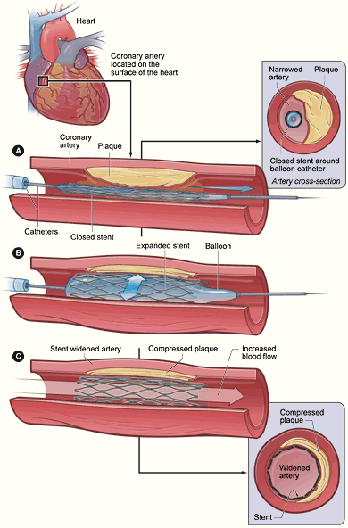

Figura: Stents no tratamento de AVC

## Estudo de Caso: stents e prevenção de AVC

Os pesquisadores do estudo investigaram se havia benefícios também para pacientes com risco de AVC.

- Pergunta de interesse:

O uso de stent reduz o risco de AVC?

- Os pesquisadores coletaram dados de 451 pacientes com risco de AVC que se voluntariaram para o estudo.

Cada paciente foi alocado aleatoriamente em um dos grupos:

- **Grupo de Tratamento** - paciente recebe stent e medicação.
- **Grupo Controle** - paciente recebe a mesma medicação do grupo tratamento, mas não recebe stent.

## Estudo de Caso: stents e prevenção de AVC

Cada paciente foi avaliado em duas ocasiões: primeiros 30 dias e após 1 ano.

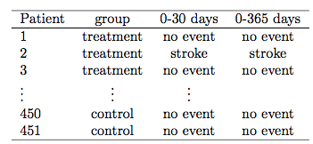

Avaliar cada paciente individualmente desta planilha de dados é eficaz?

Como poderíamos resumir?

## Estudo de Caso: stents e prevenção de AVC

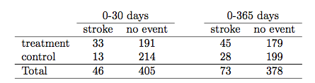

33 pacientes do grupo tratamento tiveram um AVC durante os primeiros 30 dias.

Dentre os 224 pacientes do grupo tratamento, 45 tiveram AVC durante o primeiro ano.

Qual a proporção de pacientes do grupo tratamento que sofreram AVC durante o primeiro ano?

\[45/224=0.2 = 20\%\]

## Estudo de Caso: stents e prevenção de AVC

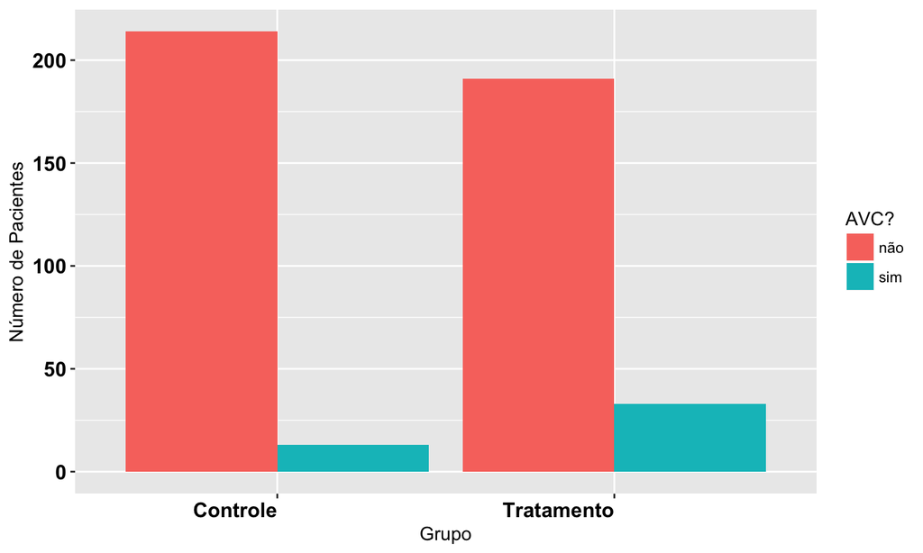

## Estudo de Caso: stents e prevenção de AVC

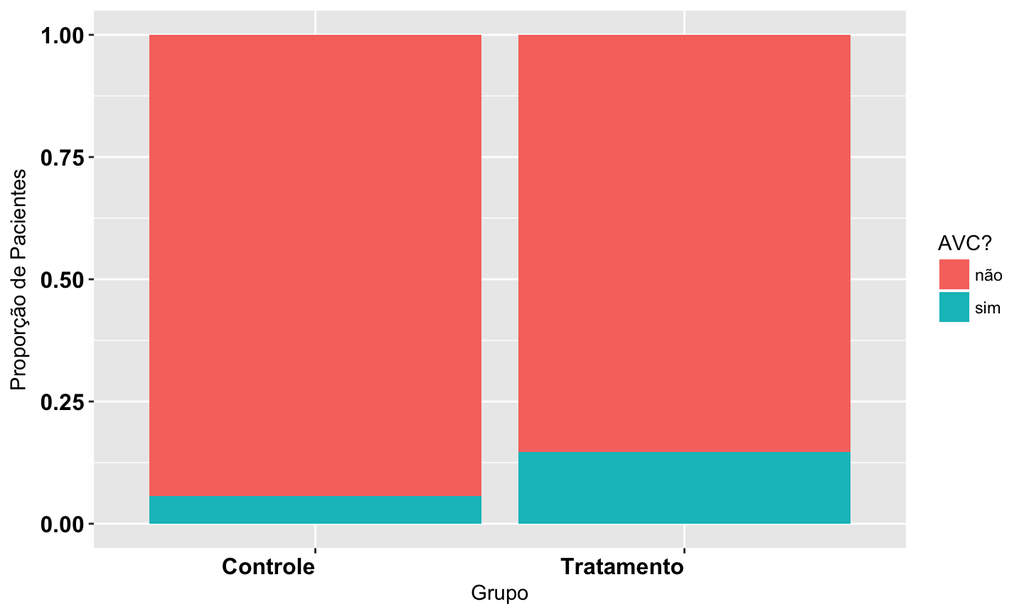

## Estudo de Caso: stents e prevenção de AVC

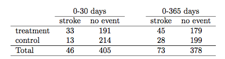

Podemos calcular **estatísticas sumárias** a partir da tabela.

**Estatística Sumária**: número obtido a partir de informações dos dados coletados para resumí-los.

Proporção de pacientes do grupo tratamento que sofreram AVC: \[45/224=0.2 = 20\%\]

Proporção de pacientes do grupo controle que sofreram AVC: \[28/227=0.12 = 12\%\]

## Estudo de Caso: stents e prevenção de AVC

No grupo tratamento, temos 8% a mais de pacientes que sofreram AVC.

Isto está de acordo com a expectativa dos pesquisadores do estudo? (relembre a pergunta de interesse)

8% é uma diferença **considerável**?

Uma diferença de 8% poderia acontecer ao acaso, mesmo que os dois tratamentos na verdade oferecessem o mesmo risco de AVC?

Utilizando metodologia estatística, os pesquisadores chegaram à conclusão de que stents são prejudiciais para pacientes com risco de AVC.

## Estudo de Caso: stents e prevenção de AVC

**CUIDADO!**

Não podemos generalizar os resultados do estudo para todo tipo de paciente e todo tipo de stent.

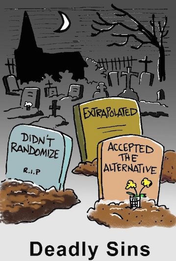

## Estatística Descritiva: Introdução

## Exemplo: Dados do Censo

É mais simples olharmos gráficos ou 35.723.254 questionários?

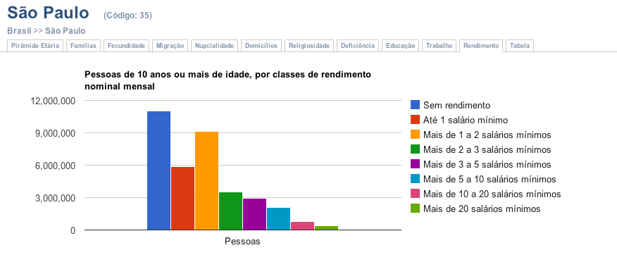

Fonte: http://www.censo2010.ibge.gov.br

## Estatística Descritiva: Estrutura básica de dados

## Estrutura dos dados

Para que possamos resumir os dados, é importante primeiramente entender como eles são organizados e também os diversos tipos de cada variável.

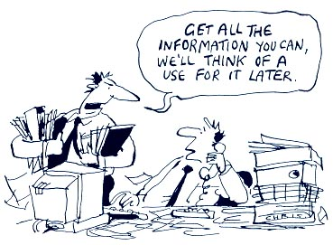

## Exemplo: Hepatite

Fonte: http://archive.ics.uci.edu/ml/datasets/Hepatitis

| Class | Age | Sex | anorexia | liver big | bilirubin | alk phosphate | sgot | albumin |
| --- | --- | --- | --- | --- | --- | --- | --- | --- |
| 2 | 30 | 2 | 2 | 1 | 1.00 | 85 | 18 | 4.0 |
| 2 | 50 | 1 | 2 | 1 | 0.90 | 135 | 42 | 3.5 |
| 2 | 78 | 1 | 2 | 2 | 0.70 | 96 | 32 | 4.0 |
| 2 | 31 | 1 | 2 | 2 | 0.70 | 46 | 52 | 4.0 |
| 2 | 34 | 1 | 2 | 2 | 1.00 | ? | 200 | 4.0 |
| 2 | 34 | 1 | 2 | 2 | 0.90 | 95 | 28 | 4.0 |
| 1 | 51 | 1 | 1 | 2 | ? | ? | ? | ? |
| 2 | 23 | 1 | 2 | 2 | 1.00 | ? | ? | ? |
| 2 | 39 | 1 | 2 | 2 | 0.70 | ? | 48 | 4.4 |
| 2 | 30 | 1 | 2 | 2 | 1.00 | ? | 120 | 3.9 |
| 2 | 39 | 1 | 2 | 1 | 1.30 | 78 | 30 | 4.4 |
| 2 | 32 | 1 | 2 | 2 | 1.00 | 59 | 249 | 3.7 |
| 2 | 41 | 1 | 2 | 2 | 0.90 | 81 | 60 | 3.9 |
| 2 | 30 | 1 | 2 | 2 | 2.20 | 57 | 144 | 4.9 |
| 2 | 47 | 1 | 2 | 2 | ? | ? | 60 | ? |
| 2 | 38 | 1 | 1 | 2 | 2.00 | 72 | 89 | 2.9 |
| 2 | 66 | 1 | 2 | 2 | 1.20 | 102 | 53 | 4.3 |
| 2 | 40 | 1 | 2 | 2 | 0.60 | 62 | 166 | 4.0 |
| 2 | 38 | 1 | 2 | 2 | 0.70 | 53 | 42 | 4.1 |
| 2 | 38 | 1 | 2 | 1 | 0.70 | 70 | 28 | 4.2 |
| 2 | 22 | 2 | 2 | 2 | 0.90 | 48 | 20 | 4.2 |
| 2 | 27 | 1 | 1 | 1 | 1.20 | 133 | 98 | 4.1 |
| 2 | 31 | 1 | 2 | 2 | 1.00 | 85 | 20 | 4.0 |
| 2 | 42 | 1 | 2 | 2 | 0.90 | 60 | 63 | 4.7 |
| 2 | 25 | 2 | 2 | 2 | 0.40 | 45 | 18 | 4.3 |
| 2 | 27 | 1 | 2 | 2 | 0.80 | 95 | 46 | 3.8 |
| 2 | 49 | 1 | 1 | 2 | 0.60 | 85 | 48 | 3.7 |
| 2 | 58 | 2 | 2 | 2 | 1.40 | 175 | 55 | 2.7 |
| 2 | 61 | 1 | 2 | 1 | 1.30 | 78 | 25 | 3.8 |
| 2 | 51 | 1 | 2 | 2 | 1.00 | 78 | 58 | 4.6 |

[output cut: 125 more lines]

## Exemplo: Hepatite

[Descrição dos dados](http://archive.ics.uci.edu/ml/machine-learning-databases/hepatitis/hepatitis.names)

- 155 pacientes (linhas da planilha)

Colunas:

- Class: DIE, LIVE
- AGE: 10, 20, 30, 40, 50, 60, 70, 80
- SEX: male, female
- ANOREXIA: no, yes
- LIVER BIG: no, yes
- BILIRUBIN: 0.39, 0.80, 1.20, 2.00, 3.00, 4.00
- ALK PHOSPHATE: 33, 80, 120, 160, 200, 250
- SGOT: 13, 100, 200, 300, 400, 500,
- ALBUMIN: 2.1, 3.0, 3.8, 4.5, 5.0, 6.0

## Tipos de variável

- Variável é uma condição ou característica de um elemento de estudo.
- Pode assumir valores diferentes em diferentes elementos.
- Peso, altura, curso, são exemplos de variáveis: para cada pessoa, os valores mudam.

## Tipos de variável

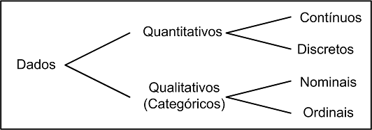

## Tipos de variável

- **Qualitativa**
  - Nominal: Não existe ordenação (ex: sexo, estado civil, profissão)
  - Ordinal: Existe uma certa ordem (ex: escolaridade, estágio da doença, classe social)
- **Quantitativa**
  - Discreta: os valores possíveis formam um conjunto finito ou enumerável (ex: número de filhos)
  - Contínua: os valores possíveis estão dentro de um intervalo, aberto ou fechado, dos números reais (ex: peso, altura, salário)

## Exemplo

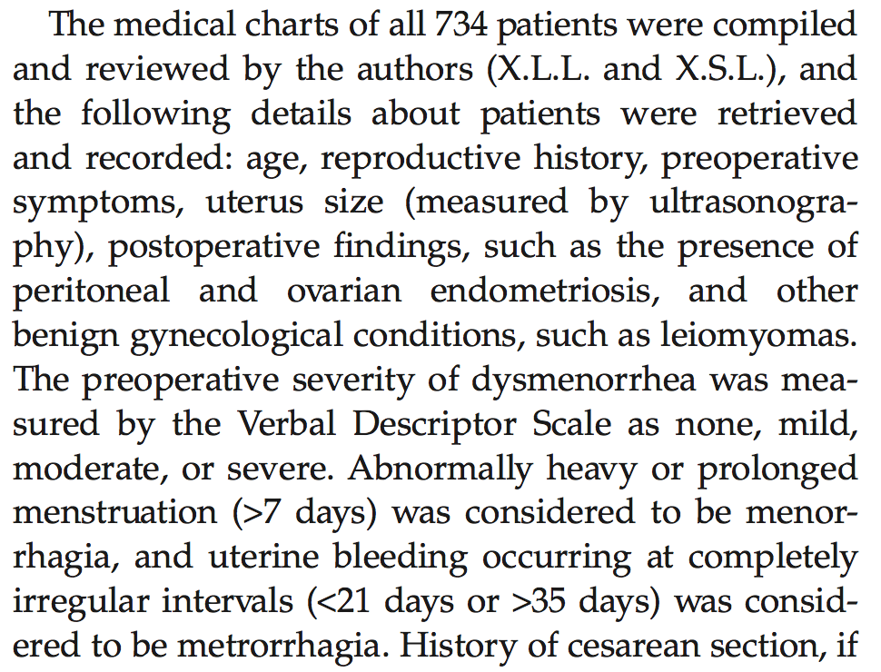

## Exemplo

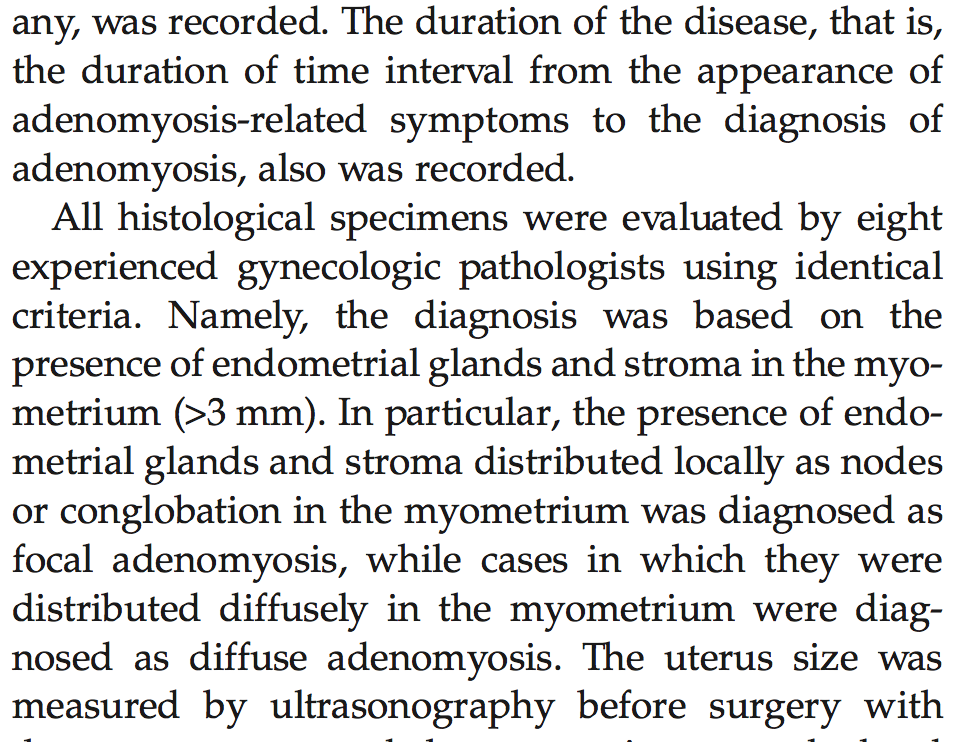

## Exemplo

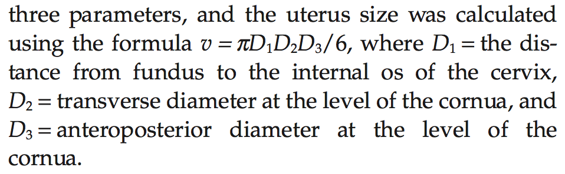

## Exemplo

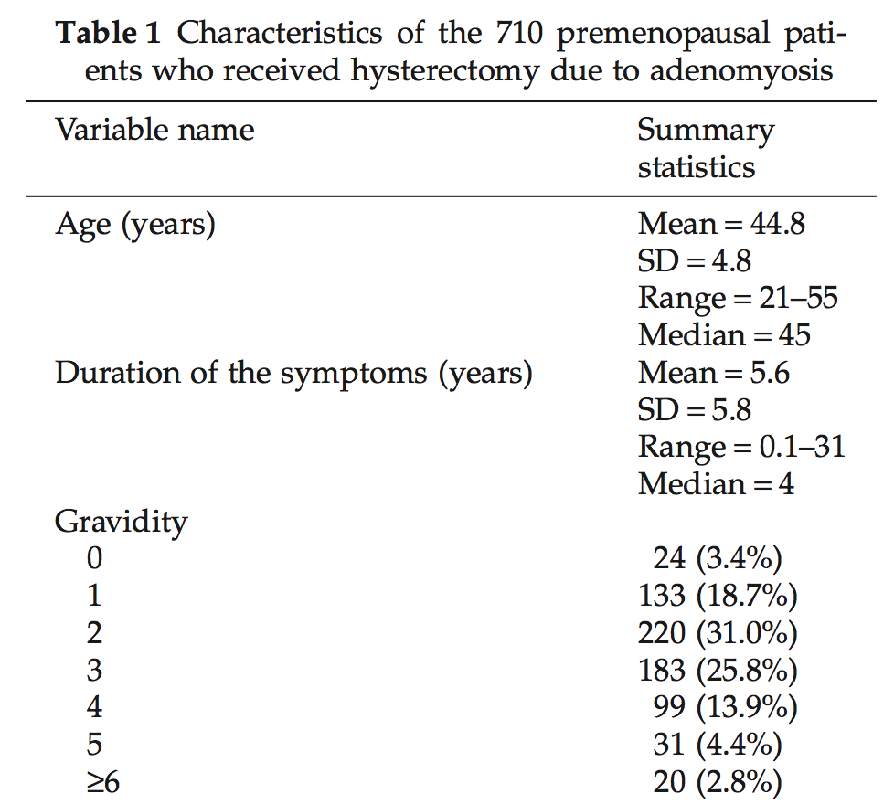

## Exemplo

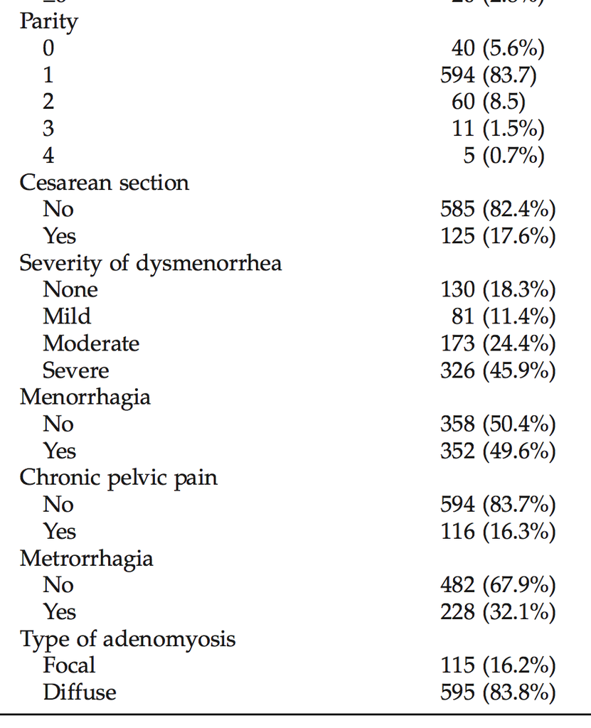

## Resumindo Dados Categóricos: Frequências e Proporções

## Dados categóricos

O primeiro passo para resumir numericamente os dados de uma variável é olhar para todos os valores possíveis e contar quantas vezes cada um aparece.

**Exemplo**: No conjunto de dados do exemplo sobre hepatite, temos a variável categórica `liver big`.

Podemos fazer uma **Tabela de frequência**, ou seja, simplesmente contar quantos pacientes se encontram em cada categoria da variável `liver big`:

```
##
##   ?   1   2 Sum
##  10  25 120 155
```

## Exemplo

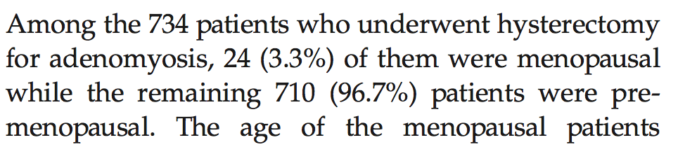

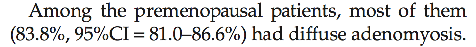

## Resumindo Dados Categóricos: Representação Gráfica

## Exemplo: Hepatite

Gráfico de barras das frequências

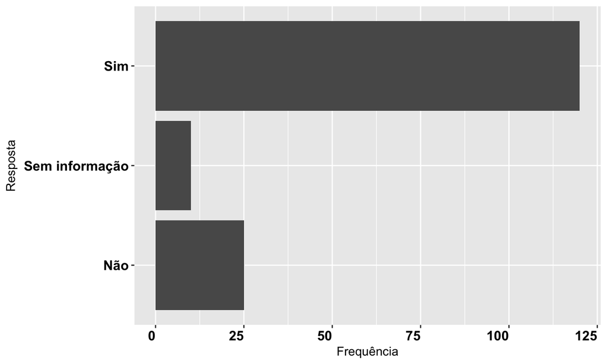

## Exemplo: Hepatite

Gráfico de barras das proporções

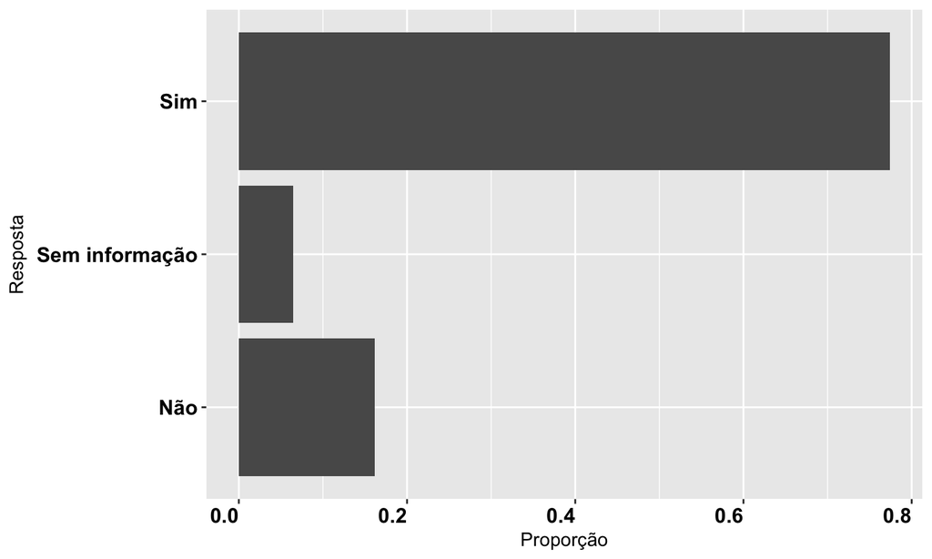

## Exemplo

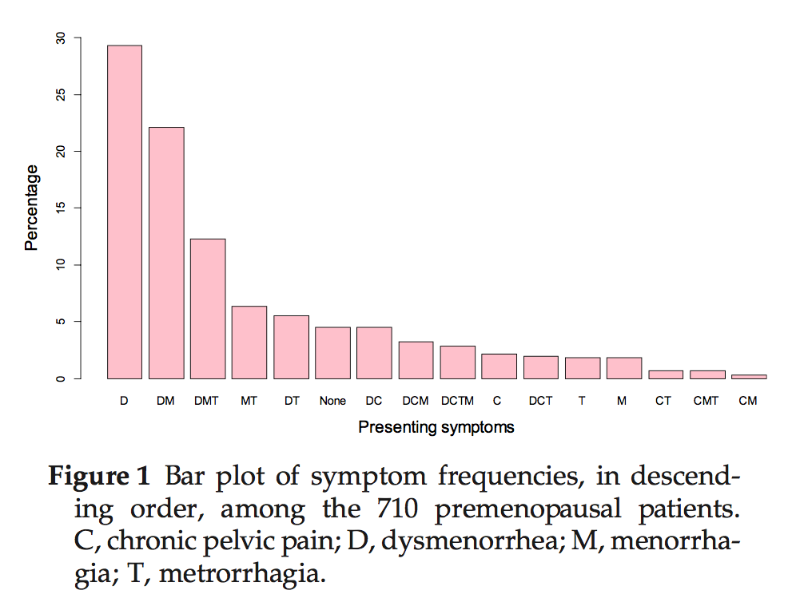

## Exemplo

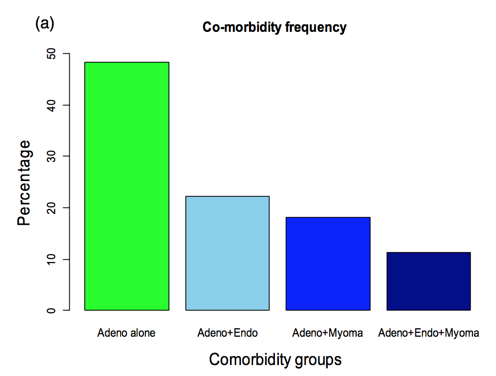

## Resumindo Dados Quantitativos

## Descrevendo Dados Quantitativos

Como estudar a distribuição de frequências de uma variável quantitativa?

**Quantitativa Discreta:** listar todos os valores possíveis nos dados e contar quantas vezes cada valor ocorre.

**Exemplo: Licença Médica**

Os dados a seguir representam o número de dias de licença médica de 50 funcionários de uma fábrica nas últimas 6 semanas:

```
##  [1] 2 2 0 0 5 8 3 4 1 0 0 7 1 7 1 5 4 0 4 0 1 8 9 7 0 1 7 2 5 5 4 3 3 0 0
## [36] 2 5 1 3 0 1 0 2 4 5 0 5 7 5 1
```

## Exemplo: Licença Médica

Como o número de valores distintos nos dados é pequeno, podemos usar uma tabela para apresentar a frequência de cada valor:

```
##   Dias de licença Frequência Proporção
## 1               0         12      0.24
## 2               1          8      0.16
## 3               2          5      0.10
## 4               3          4      0.08
## 5               4          5      0.10
## 6               5          8      0.16
## 7               7          5      0.10
## 8               8          2      0.04
## 9               9          1      0.02
```

## Exemplo: Licença Médica

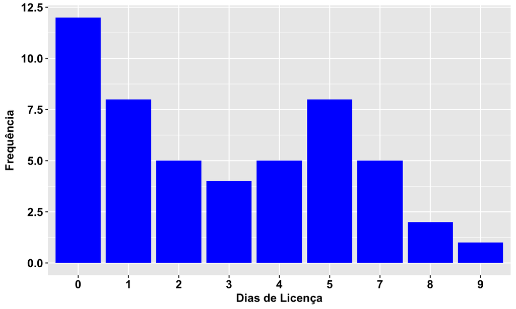

## Exemplo: Licença Médica

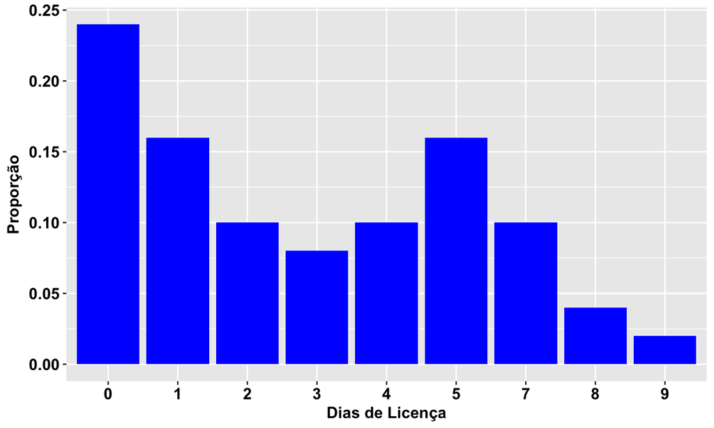

## Descrevendo Dados Quantitativos

Como estudar a distribuição de frequências de uma variável quantitativa?

**Quantitativa Contínua:** listar todos os valores possíveis nos dados e contar quantas vezes cada valor ocorre??? É eficiente?

## Histograma

- Ordene os dados do menor para o maior.
- Escolha intervalos de maneira que cada observação possa ser incluída em exatamente um deles.
- Neste curso: os intervalos são abertos à esquerda e fechados à direita \((a,b]\).
- Construa uma tabela de frequências
- Desenhe o gráfico: a altura corresponde à frequência do intervalo.

## Exemplo: Hepatite

Os dados a seguir representam o nível de bilirrubina de 40 pacientes:

```
##  [1] 1.0 0.9 0.7 0.7 1.0 0.9 1.0 0.7 1.0 1.3 1.0 0.9 2.2 2.0 1.2 0.6 0.7
## [18] 0.7 0.9 1.2 1.0 0.9 0.4 0.8 0.6 1.4 1.3 1.0 2.3 1.0 0.7 0.5 0.9 0.6
## [35] 1.3 2.3 1.0 0.3 0.7 4.6
```

> Ordenando:

```
##  [1] 0.3 0.4 0.5 0.6 0.6 0.6 0.7 0.7 0.7 0.7 0.7 0.7 0.7 0.8 0.9 0.9 0.9
## [18] 0.9 0.9 0.9 1.0 1.0 1.0 1.0 1.0 1.0 1.0 1.0 1.0 1.2 1.2 1.3 1.3 1.3
## [35] 1.4 2.0 2.2 2.3 2.3 4.6
```

## Exemplo: Hepatite

Dados ordenados:

```
##  [1] 0.3 0.4 0.5 0.6 0.6 0.6 0.7 0.7 0.7 0.7 0.7 0.7 0.7 0.8 0.9 0.9 0.9
## [18] 0.9 0.9 0.9 1.0 1.0 1.0 1.0 1.0 1.0 1.0 1.0 1.0 1.2 1.2 1.3 1.3 1.3
## [35] 1.4 2.0 2.2 2.3 2.3 4.6
```

## Exemplo: Hepatite

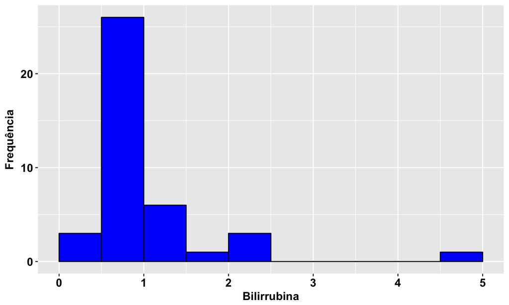

## Exemplo

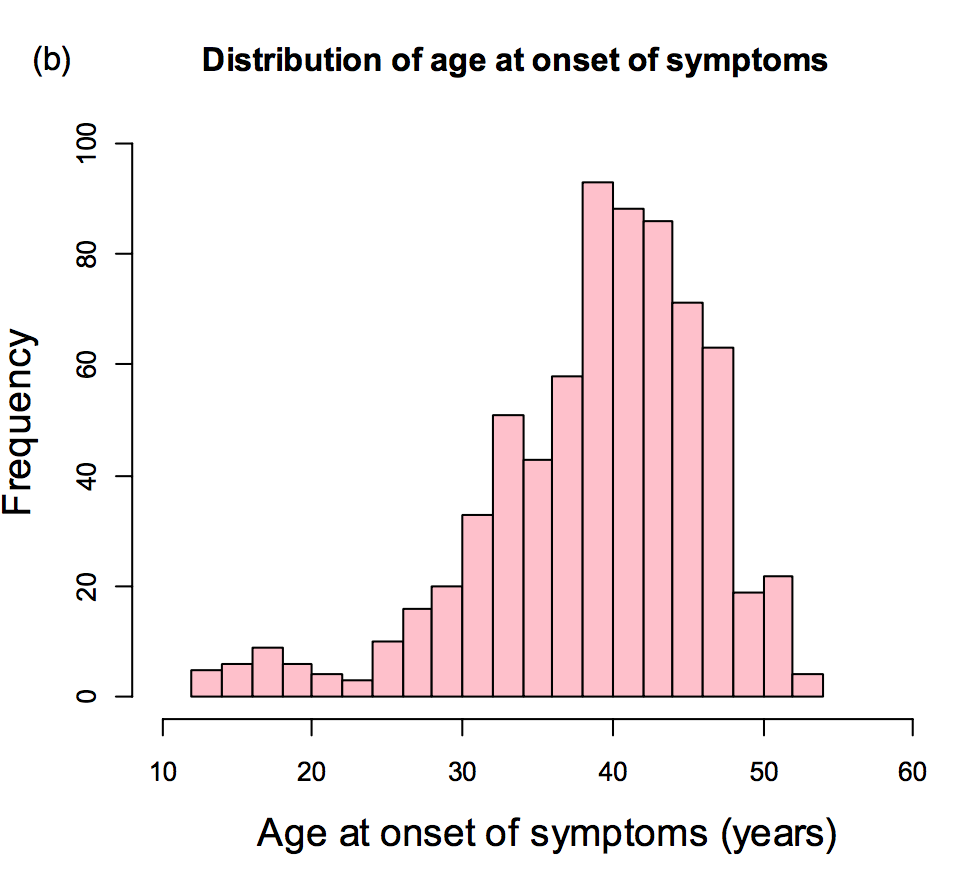

## Exemplo: vacinação nos EUA

No link http://graphics.wsj.com/infectious-diseases-and-vaccines/ temos vários gráficos mostrando muito bem o efeito de vacinas ao longo dos anos para cada estado americano, para várias doenças.

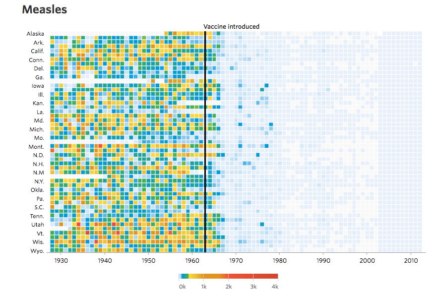

## Leitura

- [OpenIntro](https://www.openintro.org/stat/textbook.php): seções 1.1, 1.2, 1.6, 1.7
- [Ross](http://www.sciencedirect.com/science/book/9780123743886): seções 1.1, 1.2, 1.3, 1.4, 2.1, 2.2, 2.3, 2.4
- [Clinical profiles of 710 premenopausal women with adenomyosis who underwent hysterectomy](http://onlinelibrary.wiley.com/doi/10.1111/jog.12211/full)

Slides produzidos pelos professores:

- Samara Kiihl
- Tatiana Benaglia
- Benilton Carvalho
- Rafael Maia